# Logistic Regression

Steven Loaiza

February 5, 2018

## Binary Dependent Variables

As researchers we are often interested in models of choice among discrete alternative. The simplest case is where there are two outcomes.

## Linear Probability Model

The Linear Probability Model is a simple a Linear regression for binary dependent output variables. The assumption being that $Pr(Y=1|X=x)=x'\beta$, therefore we can use least square to estimate $\beta$.

We will be using data from the webpage Kaggle. There is a data set for Titanic passenger who survived the crashed. The Dependent variable will be a binary outcome, where you either survive or die.

You can downloaded the data set from [Kaggle’s webpage](https://www.kaggle.com/c/titanic/data). When you read the data into R, call it $\textbf{traindata}$. Once completed you can perform the following to clean up the data set. The procedure below is not important we are only using it to grasp the fundamentals of binary dependent variables.

```r
myvars<-c("Age","Sex","Pclass","Survived","PassengerId","Fare")
traindata<-traindata[myvars]
#Replace NAs with the mean
traindata$Age[which(is.na(traindata$Age))]<-29.70
```

Lets use our Linear Probability Model on our data set. With our estimated coefficient we will now use them to get a predicted $Y$ value from our data set.

```r
LPM<-lm(Survived~Age+Sex+Pclass+PassengerId+Fare,traindata)
Y_Pred<-predict(LPM,traindata)
summary(Y_Pred)
```

```
##    Min. 1st Qu.  Median    Mean 3rd Qu.    Max.
## -0.1340  0.1033  0.3015  0.3838  0.6183  1.0904
```

There is a huge problem using this linear model to predict our binary outcome variable. Our outcome is not bounded between zero and one. We get values that are outside the scope of the dependent variable.

## Logistic Regression

We need a nonlinear model that bounds our output values between zero and one.
$$Pr(Y=1|X)=G(z)$$
where,
$$G(z)=\frac{1}{1+e^{-z}}$$
$G(z)$ is called a Logit and it is bounded between zero and one.

$\textbf{Proof:}$
$$lim_{z-> \infty} \frac{1}{1+e^{-z}} = lim_{z-> \infty}\frac{1}{1+\frac{1}{e^z}}$$
$$lim_{z-> \infty} \frac{1}{1+\frac{1}{\infty}}= \frac{1}{1+0}=1$$
and,

$$lim_{z-> \infty} \frac{1}{1+e^{-z}}= lim_{z-> \infty} \frac{1}{1+\infty}=\frac{1}{\infty}=0$$
QED.

Lets view a plot of the logit function.

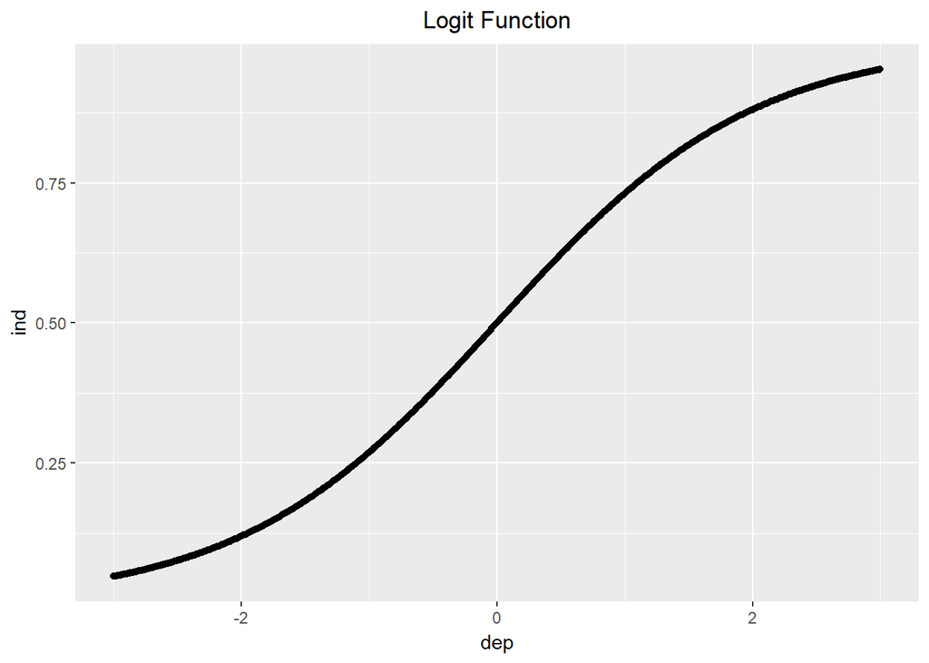

For our intent and purposes, $z=X'\beta$. How do we solve for $\beta$. There is no closed form solution for these estimators, instead we would use Maximum Liklihood functions and numerical algorithm to get the estimates. For more technical information about the logit model please see the appendix.

## Estimation

The following code will perform the logit regression on our data.

```r
model<-glm(Survived~Age+Sex+Pclass+PassengerId+Fare,traindata,family=binomial)
summary(model)
```

```
##
## Call:
## glm(formula = Survived ~ Age + Sex + Pclass + PassengerId + Fare,
##     family = binomial, data = traindata)
##
## Deviance Residuals:
##     Min       1Q   Median       3Q      Max
## -2.6646  -0.6531  -0.4205   0.6307   2.4293
##
## Coefficients:
##               Estimate Std. Error z value Pr(>|z|)
## (Intercept)  4.6164258  0.5292886   8.722  < 2e-16 ***
## Age         -0.0332830  0.0073793  -4.510 6.47e-06 ***
## Sexmale     -2.6103973  0.1877437 -13.904  < 2e-16 ***
## Pclass      -1.1490647  0.1352641  -8.495  < 2e-16 ***
## PassengerId  0.0001102  0.0003408   0.323    0.746
## Fare         0.0005753  0.0020345   0.283    0.777
## ---
## Signif. codes:  0 '***' 0.001 '**' 0.01 '*' 0.05 '.' 0.1 ' ' 1
##
## (Dispersion parameter for binomial family taken to be 1)
##
##     Null deviance: 1186.66  on 890  degrees of freedom
## Residual deviance:  805.14  on 885  degrees of freedom
## AIC: 817.14
##
## Number of Fisher Scoring iterations: 5
```

Now let see how well our model predicted who survived in the data set.

```r
#using type="response" will return the predicted probabilities
predict<-predict(model,type='response')
# we will use 0.5 as the threshold
table(traindata$Survived,predict>0.5)
```

```
##
##     FALSE TRUE
##   0   470   79
##   1    98  244
```

## Conclusion

The objective of this lesson was to show the model at work, not that it was the best predictive method for this data set.

## Appendix

### MLE of the Logit Model

$Y^*_i=X'_i\theta+\epsilon_i$ Latent (Hidden, unobserved) Variable Model. We are able to observe $Y_i = {1 \quad if \quad Y^*_i > 0;\quad 0 \quad \textrm{otherwise}}$

$\underline{Remark}:\quad\sigma^2_\epsilon$ by itself can’t be identified, only the ration $\frac{\beta}{\sigma_\epsilon}$. Therefore, we can only identify $\beta$ up to a scale factor. $Y_i=1$ with $Pr(\epsilon_i>-X'_i\beta)=Pr(\frac{\epsilon}{\alpha}.-X'_i\frac{\beta}{\alpha})$ for $\alpha>0$. We are unable to tell the difference between $beta$ and $\frac{\beta}{\alpha}$.

$\underline{Assumptions}:\quad \epsilon$ distribution is known;Also $\epsilon$ and $X$ are orthogonal (independent).

Let $Pr(Y_i=1|X_i, \beta)=p(X_i,\theta)=1-F(-X'_i\theta)$, where $F$ is the CDF function of $epsilon$.

Below are some of the moments of our model:
$$E(Y_i|X_i)=P_i$$
$$Var(Y_i|X_i)=E((X-E(X))^2)=P_i(1-P_i)$$
The log-liklihood function is:
$$Ln=\frac{1}{n}\sum^n_{i=1}(Y_iln(p(X_i,\beta))+(1-Y_i)ln(1-p(X_i,\beta)))$$
When we maximize this function with respect to $\beta$ we get:
$$\frac{\partial Ln(\beta)}{\partial \beta}=\frac{1}{n}\sum^n_{i=1}\frac{1}{\hat{P_i}(1-\hat{P_i})} \frac{\partial\hat{P_i}}{\partial \beta} (Y_i-\hat{P_i})=0$$
If we were to plug in $P_i$ which is $\frac{e^{X'_i\beta}}{1+e^{X'_i\beta}}$ there would not be a closed form solution.

### Cost Function

ML is concave, and thus the function $Ln$ is concave. Please refer to the following link that demonstrates the Logistic Regression is [convex]{http://qwone.com/~jason/writing/convexLR.pdf}. We will use an informal way to show it.

Since $Ln$ is concave(otherwise we would be unable to maximize it) then if we take the negative of that function it would be convex.Below is a simple example:

[figure not shown]

```r
g<-seq(-5,5,by=0.1)
gg<-g^2
data<-as.data.frame(cbind(gg,g))
ggplot(data,aes(x=g,y=gg))+geom_point()+ggtitle("Concave")
```

[figure not shown]

```r
ggplot(data,aes(x=g,y=-gg))+geom_point()+ggtitle("Convex")
```

Therefore we will use the following as our cost function, that we would like to minimize.
$$J(\beta)=\frac{1}{n}\sum^n_{i=1}(-Y_iln(p(X_i,\beta))-(1-Y_i)ln(1-p(X_i,\beta)))$$
This is a good cost function because it does a great job of penalizing a wrong prediction. When $Y=1$, we get the following plot for $J(\beta)= \frac{1}{n}\sum^n_{i=1}(-ln(p(X_i,\beta))$. Recall that our probability function is bounded between zero and one.

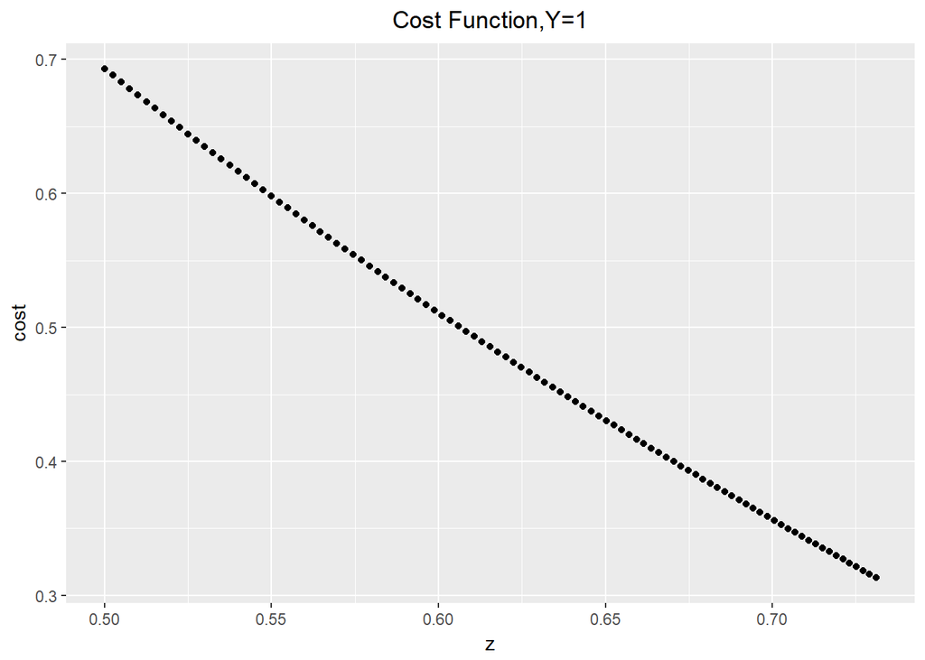

```r
q<-seq(0,1, by=0.01)
z<-exp(q)/(1+exp(q))
cost<- -log(z)
costdata<-as.data.frame(cbind(z,cost))
ggplot(costdata,aes(x=z,y=cost))+geom_point()+ggtitle("Cost Function,Y=1")
```

Note that $z$ is the predicted value of our dependent variable, since the actually binary value is one, the closer we get to predicting zero the higher the cost. Our plot above only went as low as 0.5, we will not be able to evaluate the cost at zero, because the log of zero is negative infinity.

Conversely, the cost function when $Y=0$ is:

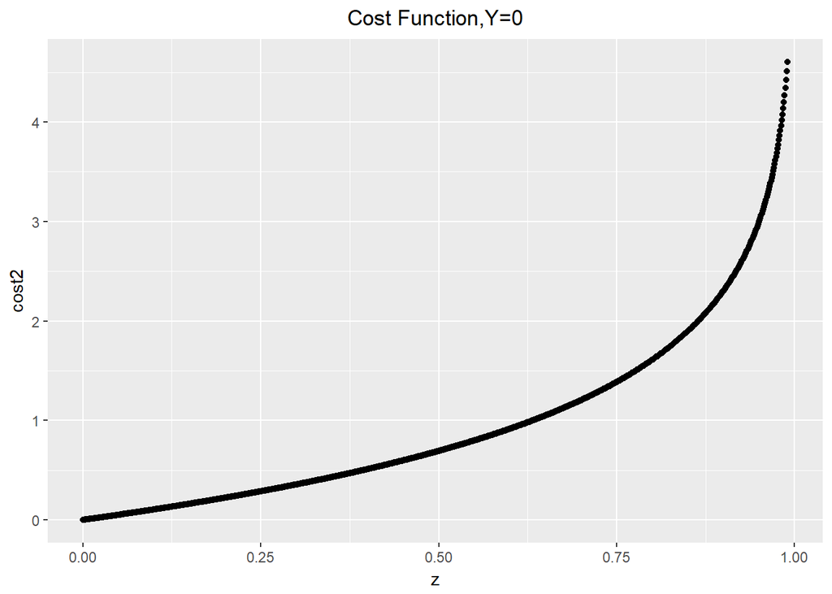

Given our cost function we could use method like gradient decent to numerically find $\beta's$ that minimize this cost function.